# Weekly Exercise

Jonas Meirer

23 9 2020

# Exercise 1, Part b

## Task

Create an HTML docuemtn that samples 100 values from a *log-normal distribution* (say, mu = 1, sigma = .25); create a histogram of the distribution and the distribution on the log scale; report the mean and variance of the sample in line in text. In general, do not just dump the R code and plots in the HTML docuement; break your exercise into sections with headings, add some text and make it readable

## Let's begin

### Data Generation

First, sample 100 values from the Log-Normal distribution:

```r
lognorm <- data.frame(Values = rlnorm(100, 1, 0.25))
```

### Visualization

In order to visualize this, we first need to load the ggplot plackage. Then we can start with the actual plotting of a **histogram**:

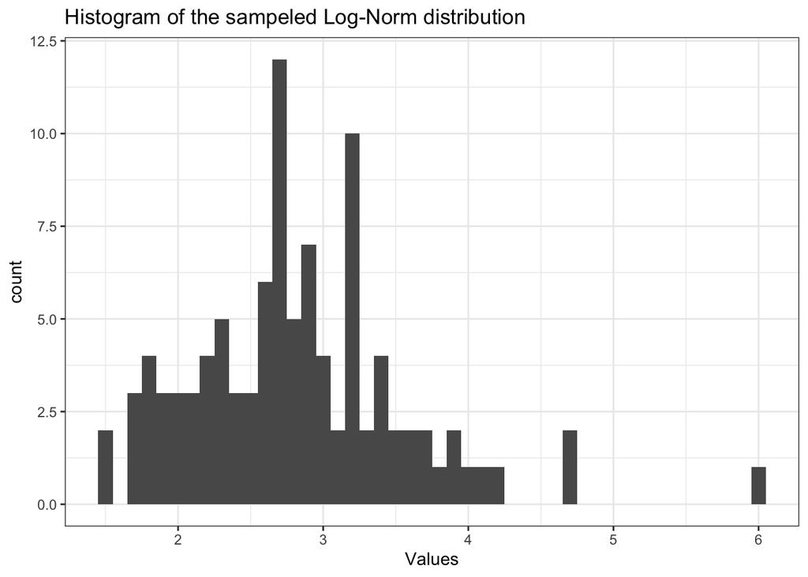

```r
library(ggplot2)
ggBase <- ggplot(data = lognorm, aes(x=Values))

ggBase+
  geom_histogram(binwidth = 0.1) +
  theme_bw() +
  ggtitle("Histogram of the sampeled Log-Norm distribution")
```

We can also take a look at the continuous **density plot**:

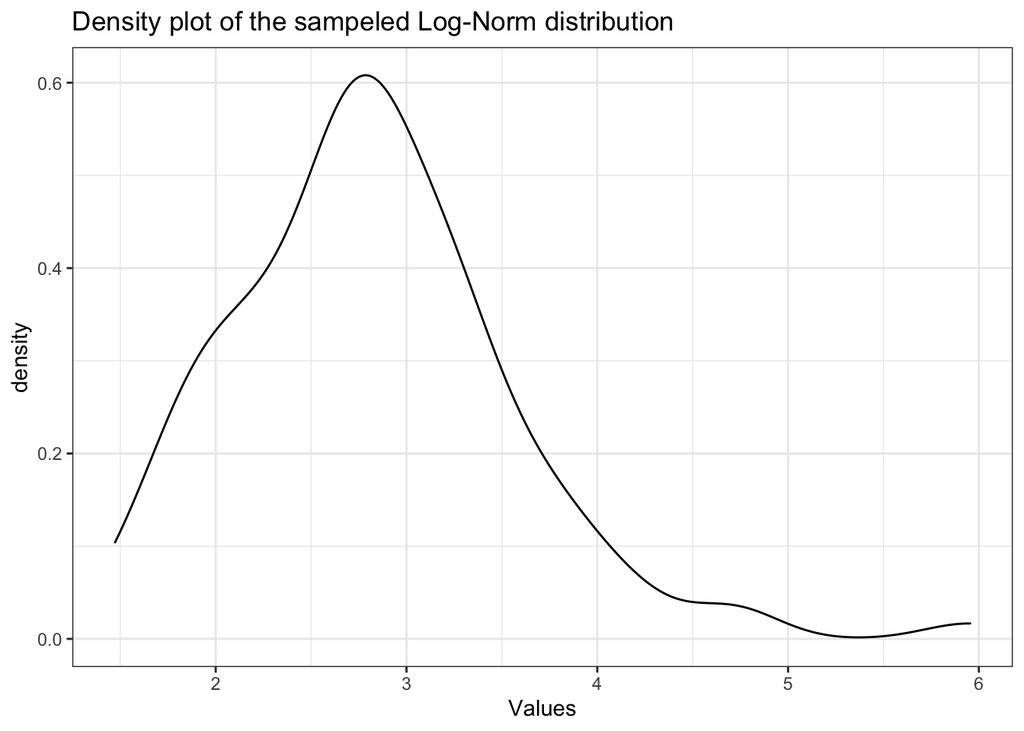

```r
ggBase +
  geom_density() +
  theme_bw() +
  ggtitle("Density plot of the sampeled Log-Norm distribution")
```

```r
log_norm_mean <- round(mean(lognorm$Values), digits = 4)
log_norm_sd   <- round(sd(lognorm$Values)  , digits = 4)
```

Now let's check how the plots change when we move a **logarithmic scale** instead:

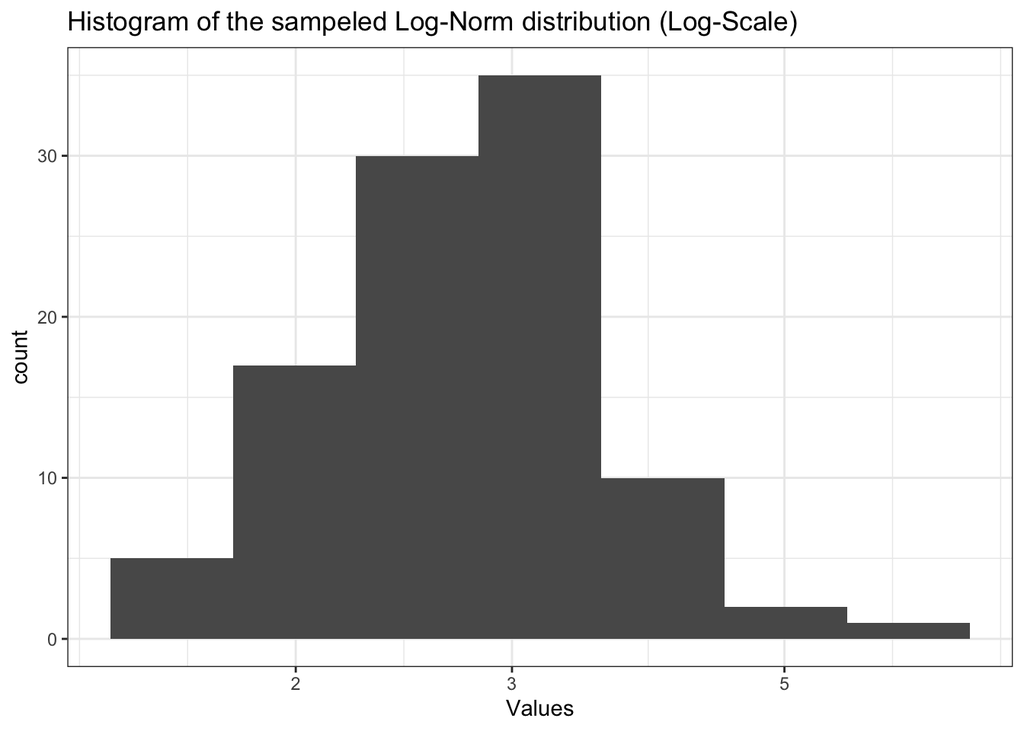

```r
ggBase+
  geom_histogram(binwidth = 0.1) +
  theme_bw() +
  ggtitle("Histogram of the sampeled Log-Norm distribution (Log-Scale)") +
  scale_x_continuous(trans = 'log10')
```

And also the **density plot**:

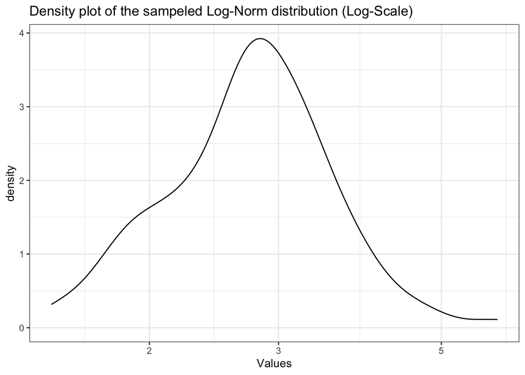

```r
ggBase +
  geom_density() +
  theme_bw() +
  ggtitle("Density plot of the sampeled Log-Norm distribution (Log-Scale)") +
 scale_x_continuous(trans = 'log10')
```

This actually looks way more like a normal distribution, which does make sense since the log-normal distribution is characterized as the probability distribution of a variable whose logarithm is normally distributed.